# Voting patterns of Immigrants past & present

Dennis Shpits

2021-01-26

If you think of immigration as the act of importing political ideology then perhaps by focusing on voting patterns of immigrants, you can make some interesting conclusions. In contemporary discourse surrounding immigration there is a politically significant category of people known as [Dreamers](https://americasvoice.org/blog/what-is-a-dreamer/). How will the potential executive orders by the Democratic President influence the outcomes of future elections? In this R notebook we will explore the ANES dataset. Particularly we will explore how foreign born voters and their children can sway election results toward a certain party.

In order to explore immigrant voting patterns we should first look at the past. What countries were our respondents born in? Respondents born outside the US and whose parents were also born outside the US are plotted below. Keep the visual in mind because we will refer back to it later.

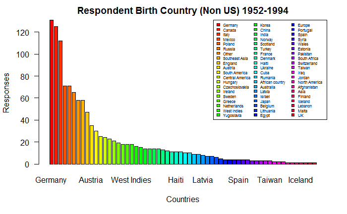

```r
save_column_Birth<-grep("VCF0142", colnames(anes_dat))

##Remove NA values from Birth Country Column
Born_cleaned<-anes_dat[complete.cases(anes_dat[save_column_Birth]),]

##Remove people born in the US
non_us_Born_cleaned<-Born_cleaned %>% filter(VCF0142 > 199)

##Remove if both parents born in US
non_us_Born_cleaned_parents_too<-non_us_Born_cleaned %>% filter(VCF0143 == 5)

##Filter unique people out so we have one record per respondent
non_us_Born_cleaned_unique<-non_us_Born_cleaned_parents_too[!duplicated(non_us_Born_cleaned_parents_too[ , c("VCF0006a")]),]

###Create pie chart
###pie chart of respondant origin in the entire dataset
chart_table<-select(non_us_Born_cleaned_unique, Country_of_Birth=VCF0142)

##Update to show country names

#convert column to string
string_column <- data.frame(lapply(chart_table, as.character), stringsAsFactors=FALSE)

#update each country
string_column[string_column$Country_of_Birth == 315, "Country_of_Birth"] <- "Germany"
string_column[string_column$Country_of_Birth == 351, "Country_of_Birth"] <- "Italy"
string_column[string_column$Country_of_Birth == 209, "Country_of_Birth"] <- "Canada"
string_column[string_column$Country_of_Birth == 219, "Country_of_Birth"] <- "Mexico"
string_column[string_column$Country_of_Birth == 336, "Country_of_Birth"] <- "Poland"
string_column[string_column$Country_of_Birth == 337, "Country_of_Birth"] <- "Russia"
string_column[string_column$Country_of_Birth == 301, "Country_of_Birth"] <- "England"
string_column[string_column$Country_of_Birth == 428, "Country_of_Birth"] <- "Southeast Asia"
string_column[string_column$Country_of_Birth == 310, "Country_of_Birth"] <- "Austria"
string_column[string_column$Country_of_Birth == 259, "Country_of_Birth"] <- "South America"
string_column[string_column$Country_of_Birth == 302, "Country_of_Birth"] <- "Ireland"
string_column[string_column$Country_of_Birth == 333, "Country_of_Birth"] <- "Hungary"
string_column[string_column$Country_of_Birth == 324, "Country_of_Birth"] <- "Sweden"
string_column[string_column$Country_of_Birth == 331, "Country_of_Birth"] <- "Czechoslovakia"
string_column[string_column$Country_of_Birth == 343, "Country_of_Birth"] <- "Greece"
string_column[string_column$Country_of_Birth == 317, "Country_of_Birth"] <- "Netherlands"
string_column[string_column$Country_of_Birth == 323, "Country_of_Birth"] <- "Norway"
string_column[string_column$Country_of_Birth == 312, "Country_of_Birth"] <- "France"
string_column[string_column$Country_of_Birth == 303, "Country_of_Birth"] <- "Scotland"
string_column[string_column$Country_of_Birth == 345, "Country_of_Birth"] <- "Yugoslavia"
string_column[string_column$Country_of_Birth == 404, "Country_of_Birth"] <- "India"
string_column[string_column$Country_of_Birth == 431, "Country_of_Birth"] <- "China"
string_column[string_column$Country_of_Birth == 452, "Country_of_Birth"] <- "Korea"
string_column[string_column$Country_of_Birth == 509, "Country_of_Birth"] <- "Turkey"
string_column[string_column$Country_of_Birth == 338, "Country_of_Birth"] <- "Ukraine"
string_column[string_column$Country_of_Birth == 451, "Country_of_Birth"] <- "Japan"
string_column[string_column$Country_of_Birth == 235, "Country_of_Birth"] <- "Haiti"
string_column[string_column$Country_of_Birth == 313, "Country_of_Birth"] <- "Germany"
string_column[string_column$Country_of_Birth == 321, "Country_of_Birth"] <- "Denmark"
string_column[string_column$Country_of_Birth == 208, "Country_of_Birth"] <- "Canada"
string_column[string_column$Country_of_Birth == 233, "Country_of_Birth"] <- "Cuba"
string_column[string_column$Country_of_Birth == 344, "Country_of_Birth"] <- "Rumania"
string_column[string_column$Country_of_Birth == 207, "Country_of_Birth"] <- "Canada"
string_column[string_column$Country_of_Birth == 334, "Country_of_Birth"] <- "Latvia"
string_column[string_column$Country_of_Birth == 699, "Country_of_Birth"] <- "African country"
string_column[string_column$Country_of_Birth == 704, "Country_of_Birth"] <- "Australia"
string_column[string_column$Country_of_Birth == 239, "Country_of_Birth"] <- "West Indies"
string_column[string_column$Country_of_Birth == 311, "Country_of_Birth"] <- "Belgium"
string_column[string_column$Country_of_Birth == 504, "Country_of_Birth"] <- "Israel"
string_column[string_column$Country_of_Birth == 231, "Country_of_Birth"] <- "West Indies"
string_column[string_column$Country_of_Birth == 335, "Country_of_Birth"] <- "Lithuania"
string_column[string_column$Country_of_Birth == 353, "Country_of_Birth"] <- "Spain"
string_column[string_column$Country_of_Birth == 237, "Country_of_Birth"] <- "West Indies"
string_column[string_column$Country_of_Birth == 238, "Country_of_Birth"] <- "West Indies"
string_column[string_column$Country_of_Birth == 304, "Country_of_Birth"] <- "Wales"
string_column[string_column$Country_of_Birth == 318, "Country_of_Birth"] <- "Switzerland"
string_column[string_column$Country_of_Birth == 352, "Country_of_Birth"] <- "Portugal"
string_column[string_column$Country_of_Birth == 229, "Country_of_Birth"] <- "Central America"
string_column[string_column$Country_of_Birth == 229, "Country_of_Birth"] <- "Central America"
string_column[string_column$Country_of_Birth == 332, "Country_of_Birth"] <- "Estonia"
string_column[string_column$Country_of_Birth == 399, "Country_of_Birth"] <- "Europe"
string_column[string_column$Country_of_Birth == 406, "Country_of_Birth"] <- "Pakistan"
string_column[string_column$Country_of_Birth == 434, "Country_of_Birth"] <- "Taiwan"
string_column[string_column$Country_of_Birth == 502, "Country_of_Birth"] <- "Egypt"
string_column[string_column$Country_of_Birth == 655, "Country_of_Birth"] <- "South Africa"
string_column[string_column$Country_of_Birth == 201, "Country_of_Birth"] <- "North America"
string_column[string_column$Country_of_Birth == 314, "Country_of_Birth"] <- "Germany"
string_column[string_column$Country_of_Birth == 501, "Country_of_Birth"] <- "Egypt"
string_column[string_column$Country_of_Birth == 503, "Country_of_Birth"] <- "Iraq"
string_column[string_column$Country_of_Birth == 505, "Country_of_Birth"] <- "Jordan"
string_column[string_column$Country_of_Birth == 997, "Country_of_Birth"] <- "Other"
string_column[string_column$Country_of_Birth == 308, "Country_of_Birth"] <- "UK"
string_column[string_column$Country_of_Birth == 322, "Country_of_Birth"] <- "Finland"
string_column[string_column$Country_of_Birth == 325, "Country_of_Birth"] <- "Iceland"
string_column[string_column$Country_of_Birth == 339, "Country_of_Birth"] <- "Europe"
string_column[string_column$Country_of_Birth == 354, "Country_of_Birth"] <- "Malta"
string_column[string_column$Country_of_Birth == 401, "Country_of_Birth"] <- "Afghanistan"
string_column[string_column$Country_of_Birth == 432, "Country_of_Birth"] <- "Other"
string_column[string_column$Country_of_Birth == 499, "Country_of_Birth"] <- "Asia"
string_column[string_column$Country_of_Birth == 506, "Country_of_Birth"] <- "Lebanon"
string_column[string_column$Country_of_Birth == 232, "Country_of_Birth"] <- "Other"
string_column[string_column$Country_of_Birth == 508, "Country_of_Birth"] <- "Syria"
###########################################

x<-sort(table(string_column$Country_of_Birth), decreasing = TRUE)

##add some color and labels
barplot(x,
        col = rainbow(length(x)),
        main = "Respondent Birth Country (Non US) 1952-1994",
        xlab = "Countries",
        ylab = "Responses",
        las = 1,
)
legend("topright",
       legend = row.names(x),
       fill = rainbow(length(x)), ncol = 3,
       cex = 0.5)
```

```r
invisible({capture.output({
dev.copy(png,'../figs/allcountires.png')
dev.off()
})})
```

The US truly is a melting pot of different cultures. We do not have an even distribution of respondents from each country, but nevertheless they share one thing in common: they were not born in the US and neither were their parents. Notice how most of our immigrants are from Europe.

```r
sprintf("We have %i unique respondents that were born outside the US between 1952 and 1994", nrow(string_column))
```

```
[1] "We have 1237 unique respondents that were born outside the US between 1952 and 1994"
```

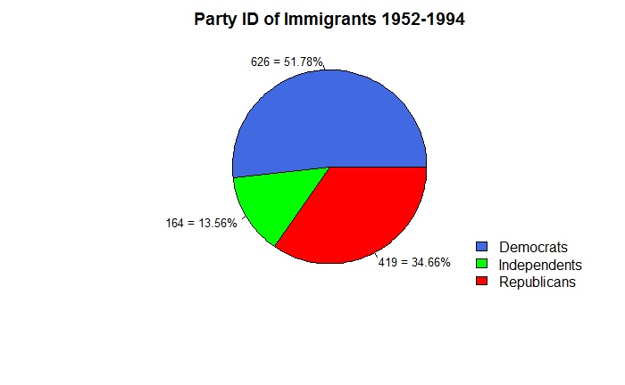

```r
###pie chart of respondent party ID
pie_chart_party<-select(non_us_Born_cleaned_unique, Party_ID=VCF0303)

pie_chart_party_cleaned<-pie_chart_party[complete.cases(pie_chart_party[1]),]

string_party_col <- data.frame(lapply(pie_chart_party_cleaned, as.character), stringsAsFactors=FALSE)

cols = c("royalblue", "green", "red")
leg = c("Democrats", "Independents", "Republicans")
#update each country
string_party_col[string_party_col$Party_ID == 1, "Party_ID"] <- "Democrats"
string_party_col[string_party_col$Party_ID == 2, "Party_ID"] <- "Independents"
string_party_col[string_party_col$Party_ID == 3, "Party_ID"] <- "Republicans"

pie_labels <- paste0(table(string_party_col), " = ", round(100 * table(string_party_col)/sum(table(string_party_col)), 2), "%")

# Plot the chart with title.
pie(table(string_party_col),cex = 0.8, main = "Party ID of Immigrants 1952-1994", col = cols, labels = pie_labels)

legend("bottomright",legend=leg,bty="n", fill=cols)
```

```r
invisible({capture.output({
dev.copy(png,'../figs/immigrantparty.png')
dev.off()
})})
```

Next we want to drill down on the above graph. We identify what backgrounds lean towards Republicans.

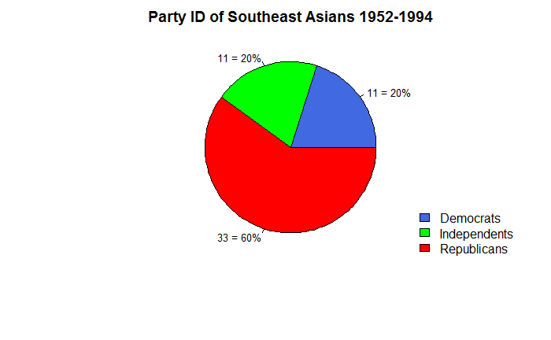

```r
party_birth_place<-select(non_us_Born_cleaned_unique, Party_ID=VCF0303, Country_of_Birth = VCF0142)

party_birth_place_cleaned<-party_birth_place[complete.cases(party_birth_place[1]),]

SEA_born<-party_birth_place_cleaned %>% filter(Country_of_Birth == 428)

string_party_col_SEA <- data.frame(lapply(SEA_born, as.character), stringsAsFactors=FALSE)

#update each country
string_party_col_SEA[string_party_col_SEA$Party_ID == 1, "Party_ID"] <- "Democrats"
string_party_col_SEA[string_party_col_SEA$Party_ID == 2, "Party_ID"] <- "Independents"
string_party_col_SEA[string_party_col_SEA$Party_ID == 3, "Party_ID"] <- "Republicans"

pie_labels <- paste0(table(string_party_col_SEA), " = ", round(100 * table(string_party_col_SEA)/sum(table(string_party_col_SEA)), 2), "%")

# Plot the chart with title.
pie(table(string_party_col_SEA$Party_ID),cex = 0.8, main = "Party ID of Southeast Asians 1952-1994", col = cols, labels = pie_labels)

legend("bottomright",legend=leg,bty="n", fill=cols)
```

```r
invisible({capture.output({
dev.copy(png,'../figs/southeastasianparty.png')
dev.off()
})})
```

Looks like Republicans had a stronghold with Southeast Asians between 1952-1994. The following places are considered to be in Southeast Asia from our ANES dataset: Indochina, Thailand, Malaysia, Burma, Philippines, Indonesia. This is mainly due to anti-communist refugees that fled those areas.

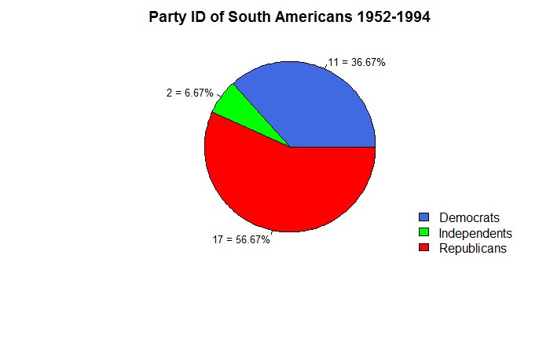

```r
South_America_born_filtered<-party_birth_place_cleaned %>% filter(Country_of_Birth == 259)


string_party_col_South_America <- data.frame(lapply(South_America_born_filtered, as.character), stringsAsFactors=FALSE)

#update each country
string_party_col_South_America[string_party_col_South_America$Party_ID == 1, "Party_ID"] <- "Democrats"
string_party_col_South_America[string_party_col_South_America$Party_ID == 2, "Party_ID"] <- "Independents"
string_party_col_South_America[string_party_col_South_America$Party_ID == 3, "Party_ID"] <- "Republicans"

pie_labels <- paste0(table(string_party_col_South_America), " = ", round(100 * table(string_party_col_South_America)/sum(table(string_party_col_South_America)), 2), "%")

# Plot the chart with title.
pie(table(string_party_col_South_America$Party_ID),cex = 0.8, main = "Party ID of South Americans 1952-1994", col = cols, labels = pie_labels)

legend("bottomright",legend=leg,bty="n", fill=cols)
```

```r
invisible({capture.output({
dev.copy(png,'../figs/southamericanparty.png')
dev.off()
})})
```

South America seems like a great place to recruit Republican voters in the years between 1952 and 1994.

Most of the Republican South American Immigrants viewed religion as important. I’m sure some of these conservative values were passed on to their children.

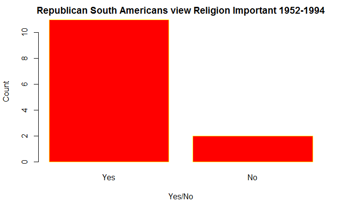

```r
SA_Analyses<-select(non_us_Born_cleaned_unique,
                          Party_ID=VCF0303,
                          Country_of_Birth = VCF0142,
                          Religion_important = VCF0846
                          )

SA_cleaned<-SA_Analyses[complete.cases(SA_Analyses[1]),]

SA_Analyses_born<-SA_cleaned %>% filter(Country_of_Birth == 259)

Only_Rep_SA<-SA_Analyses_born %>% filter(Party_ID == 3)

scale_SA<-Only_Rep_SA %>% group_by(Religion_important) %>% summarise(count_val = n())

scale_SA_cleaned<-scale_SA[complete.cases(scale_SA[1]),]

string_scale_SA_cleaned <- data.frame(lapply(scale_SA_cleaned, as.character), stringsAsFactors=FALSE)

#update each Yes/no
string_scale_SA_cleaned[string_scale_SA_cleaned$Religion_important == 1, "Religion_important"] <- "Yes"
string_scale_SA_cleaned[string_scale_SA_cleaned$Religion_important == 2, "Religion_important"] <- "No"

barplot(as.integer(string_scale_SA_cleaned$count_val),names.arg=string_scale_SA_cleaned$Religion_important,xlab="Yes/No",ylab="Count",col="red",
        main="Republican South Americans view Religion Important 1952-1994",border="yellow")
```

```r
invisible({capture.output({
dev.copy(png,'../figs/southamericanreligion.png')
dev.off()
})})
```

In order to see how Immigrants can impact elections we see if there is an increase in eligible voter population. With an increase in eligible voter population is there a clear winning trend for a certain party?

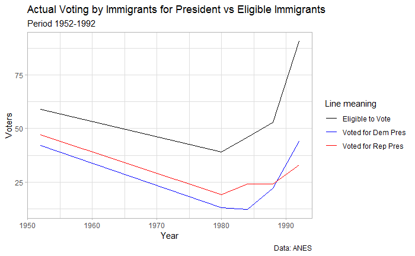

```r
save_column<-grep("VCF0704a", colnames(non_us_Born_cleaned_parents_too))

eligible_save_column<-grep("VCF0737", colnames(non_us_Born_cleaned_parents_too))

eligible<-non_us_Born_cleaned_parents_too[complete.cases(non_us_Born_cleaned_parents_too[eligible_save_column]),]

Which_President_Party_vote<-non_us_Born_cleaned_parents_too[complete.cases(non_us_Born_cleaned_parents_too[save_column]),]

#voted Democrat
Which_President_Dem_vote<-Which_President_Party_vote %>% filter(VCF0704a == 1)

#voted Republican
Which_President_Rep_vote<-Which_President_Party_vote %>% filter(VCF0704a == 2)

#eligble to vote
yes_eligible<-eligible %>% filter(VCF0737 == 2)

#change theme
theme_set(theme_light())

#change column names
President_Dem_vote_years<-select(Which_President_Dem_vote, Party_Vote=VCF0704a, Year = VCF0004)

#change column names
President_Rep_vote_years<-select(Which_President_Rep_vote, Party_Vote=VCF0704a, Year = VCF0004)

#change column names
eligible_vote_years<-select(yes_eligible, is_eligible_to_vote=VCF0737, Year = VCF0004)

#grouped republican
President_Rep_vote_years_grouped<-President_Rep_vote_years %>% group_by(Year) %>% summarise(count_votes = n())

#grouped democrat
President_Dem_vote_years_grouped<-President_Dem_vote_years %>% group_by(Year) %>% summarise(count_votes = n())

#grouped
eligible_vote_years_grouped<-eligible_vote_years %>% group_by(Year) %>% summarise(count_voter = n())

jointdataset <- merge(President_Dem_vote_years_grouped, President_Rep_vote_years_grouped, by = 'Year')

jointdataset_eligible <- merge(jointdataset, eligible_vote_years_grouped, by = 'Year')

plt<-ggplot() + geom_line(data = jointdataset_eligible, aes(x=Year, y = count_votes.x, color = "blue")) + geom_line(data = jointdataset_eligible, aes(x=Year, y = count_votes.y, color = "red"))+geom_line(data = jointdataset_eligible,aes(x=Year, y = count_voter, color = "black"))

plt<-plt + labs(
  title = "Actual Voting by Immigrants for President vs Eligible Immigrants",
  subtitle = "Period 1952-1992",
  caption = "Data: ANES",
  x = "Year",
  y = "Voters"
  )

plt + scale_color_manual(name = "Line meaning", values = c("blue" = "blue", "red" = "red", "black" = "black" ), labels = c("Eligible to Vote", "Voted for Dem Pres", "Voted for Rep Pres"))
```

```r
invisible({capture.output({
dev.copy(png,'../figs/eligiblevsactual.png')
dev.off()
})})
```

From the limited data we have, we see in 1992 when there was a spike in new eligible voters, there were more votes for the Democratic Presidential candidate than for the Republican by our respondents.

Children of Immigrants

Unfortunately we only have respondent birth country until 1994. In order to expand our sample size we now ignore the respondent’s birth country and only look at respondents whose parents were born outside the US. This will allow us to look at more recent trends and have a greater sample size.

```r
save_column_Parents_Born<-grep("VCF0143", colnames(anes_dat))

##Remove NA values from Parents born Column
Parents_Born<-anes_dat[complete.cases(anes_dat[save_column_Parents_Born]),]

non_us_parents<-Parents_Born %>% filter(VCF0143 == 5)

##Filter unique people out so we have one record per respondent
non_us_Born_Parents_cleaned_unique<-non_us_parents[!duplicated(non_us_parents[ , c("VCF0006a")]),]

sprintf("We have %i unique respondents whose parents were born outside the US", nrow(non_us_Born_Parents_cleaned_unique))
```

```
[1] "We have 8267 unique respondents whose parents were born outside the US"
```

Refer to our pie chart above of Southeast Asian Immigrants that showed a Republican majority. If we look at today’s youth that come from an Asian background, do they still have similar views as their parents?

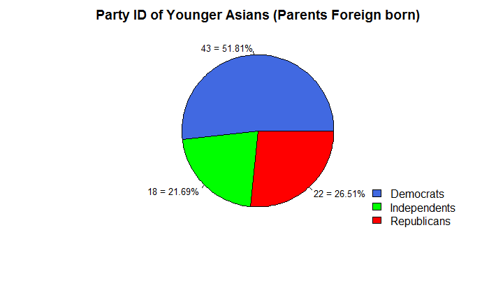

```r
recent_years<-non_us_parents %>% filter(VCF0004 > 2000)
unique_young<-recent_years[!duplicated(recent_years[ , c("VCF0006a")]),]
young_group<-unique_young %>% filter(VCF0102 < 3)
Asian_group<-young_group %>% filter(VCF0105a == 3)

party_younger_Asians<-select(Asian_group, Party_ID=VCF0303, race = VCF0105a)

party_younger_Asians <- data.frame(lapply(party_younger_Asians, as.character), stringsAsFactors=FALSE)

#update each country
party_younger_Asians[party_younger_Asians$Party_ID == 1, "Party_ID"] <- "Democrats"
party_younger_Asians[party_younger_Asians$Party_ID == 2, "Party_ID"] <- "Independents"
party_younger_Asians[party_younger_Asians$Party_ID == 3, "Party_ID"] <- "Republicans"

pie_labels <- paste0(table(party_younger_Asians), " = ", round(100 * table(party_younger_Asians)/sum(table(party_younger_Asians)), 2), "%")

# Plot the chart with title.
pie(table(party_younger_Asians$Party_ID),cex = 0.8, main = "Party ID of Younger Asians (Parents Foreign born)", col = cols, labels = pie_labels)

legend("bottomright",legend=leg,bty="n", fill=cols)
```

```r
invisible({capture.output({
dev.copy(png,'../figs/youngerasians.png')
dev.off()
})})
```

In a single generation the tide has changed. I am not the first to stumble upon this [finding](https://www.npr.org/sections/itsallpolitics/2015/09/16/439574726/how-asian-american-voters-went-from-republican-to-democratic).

Since the 1950’s there has always been a number of immigrants each election that did not participate. They were not eligible to participate in elections due to citizenship status. From our respondents that have parents born outside the US, how many of them are not eligible to vote or simply did not vote each election year?

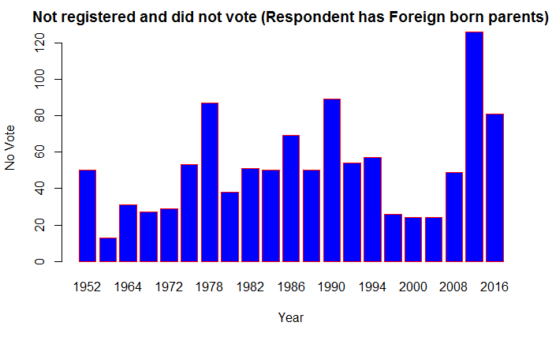

```r
not_reg_not_vote_column<-grep("VCF0703", colnames(anes_dat))

not_reg_not_vote<-non_us_parents[complete.cases(non_us_parents[not_reg_not_vote_column]),]

not_reg_not_vote_overall<-not_reg_not_vote %>% filter(VCF0703 == 1)

#change column names
eligible_vote_years_non_US_parents<-select(not_reg_not_vote_overall, not_registered_did_not_vote=VCF0703, Year = VCF0004)


#grouped by year
eligible_vote_years_non_US_parents_grouped<-eligible_vote_years_non_US_parents %>% group_by(Year) %>% summarise(count_non_voters = n())

barplot(eligible_vote_years_non_US_parents_grouped$count_non_voters,names.arg=eligible_vote_years_non_US_parents_grouped$Year,xlab="Year",ylab="No Vote",col="blue",
main="Not registered and did not vote (Respondent has Foreign born parents)",border="red")
```

```r
invisible({capture.output({
dev.copy(png,'../figs/immigrantsWhoDontVote.png')
dev.off()
})})
```

Dreamers are not citizens and therefore cannot participate in elections. This might change in the future because of new legislation to naturalize Dreamers. We want to further analyze this set of individuals. We will only look at data since 2004 since Dreamers have an average age of about 24 years old. We will only look at respondents that fall into the age groups between 17-34.

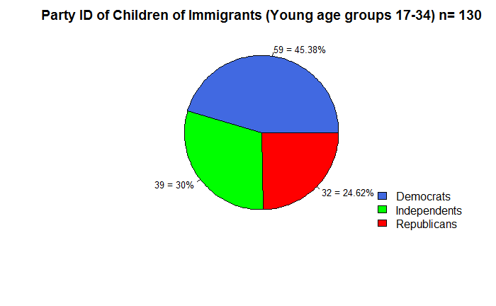

```r
non_US_parents_edu_inc_all_columns<-select(not_reg_not_vote_overall,
                                           year_case_id = VCF0006,
                                           unique_resp_num = VCF0006a,
                                           not_registered_did_not_vote=VCF0703,
                                           Year = VCF0004,
                                           Education_6_cat = VCF0140,
                                           Education_4_cat=VCF0110,
                                           Education_7_cat=VCF0140a,
                                           Hispanic_Origin = VCF0108,
                                           Age_Group=VCF0102,
                                           Political_View = VCF0303,
                                           Family_Inc_Group=VCF0114,
                                           Left_right_Scale=VCF9240,
                                           race=VCF0105a
                                           )
####Year should be greater than 2004###
recent_years<-non_US_parents_edu_inc_all_columns %>% filter(Year > 2000)
##age should be younger people
young_group<-recent_years %>% filter(Age_Group < 3)

##Filter unique people out so we have one record per respondent
unique_young<-young_group[!duplicated(young_group[ , c("unique_resp_num")]),]

save_column_pol_view<-grep("Political_View", colnames(unique_young))

##Remove NA values from Political_View
unique_young_cleaned<-unique_young[complete.cases(unique_young[save_column_pol_view]),]

string_unique_young <- data.frame(lapply(unique_young_cleaned, as.character), stringsAsFactors=FALSE)

#update each country
string_unique_young[string_unique_young$Political_View == 1, "Political_View"] <- "Democrats"
string_unique_young[string_unique_young$Political_View == 2, "Political_View"] <- "Independents"
string_unique_young[string_unique_young$Political_View == 3, "Political_View"] <- "Republicans"

pie_lab <- paste0(table(string_unique_young$Political_View), " = ", round(100 * table(string_unique_young$Political_View)/sum(table(string_unique_young$Political_View)), 2), "%")

# Plot the chart with title.
pie(table(string_unique_young$Political_View),cex = 0.8, main = paste("Party ID of Children of Immigrants (Young age groups 17-34) n=",nrow(string_unique_young)), col = cols, labels = pie_lab)

legend("bottomright",legend=leg,bty="n", fill=cols)
```

```r
invisible({capture.output({
dev.copy(png,'../figs/partyOfDreamers.png')
dev.off()
})})
```

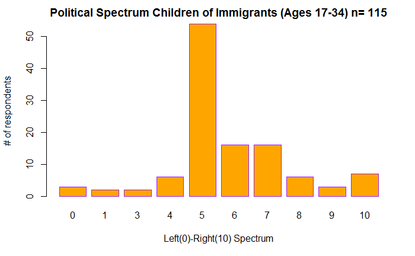

```r
save_column_spec<-grep("Left_right_Scale", colnames(unique_young))

##Remove NA values from Political_View
unique_young_cleaned_spec<-unique_young[complete.cases(unique_young[save_column_spec]),]

#change column names
spectrum<-select(unique_young_cleaned_spec, Spectrum=Left_right_Scale)


#grouped by year
spectrum_grouped<-spectrum %>% group_by(Spectrum) %>% summarise(count_spec = n())

barplot(spectrum_grouped$count_spec,names.arg=spectrum_grouped$Spectrum,xlab="Left(0)-Right(10) Spectrum",ylab="# of respondents",col="orange",
main=paste("Political Spectrum Children of Immigrants (Ages 17-34) n=", nrow(spectrum)),border="purple")
```

```r
invisible({capture.output({
dev.copy(png,'../figs/HistogramOfDreamers.png')
dev.off()
})})
```

Very few are towards the left of the political spectrum. We have more right leaning individuals. So even though the respondents are mostly democrats, their political views fall more towards moderates or conservatives.

What can we see in the differences of educational attainment of these groups? We look at respondents that are 25 or older to get a clearer idea of their final level of education.

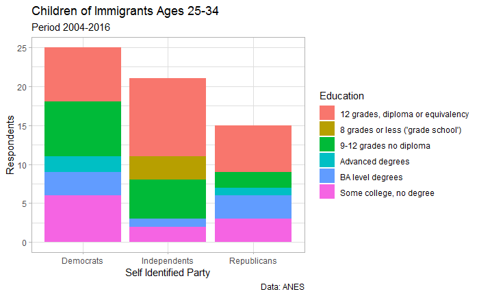

```r
age_group<-unique_young_cleaned %>% filter(Age_Group > 1)

stacked_bar<-select(age_group,
                    Education=Education_7_cat,
                    Party_Affiliation = Political_View,
                    )

stacked_bar_grouped<-stacked_bar %>% group_by(Party_Affiliation, Education) %>% summarise(count_val = n())

##Remove NA values
stacked_bar_grouped_cleaned<-stacked_bar_grouped[complete.cases(stacked_bar_grouped[2]),]

#factor_stacked_bar_grouped<-as_factor(stacked_bar_grouped_cleaned,ordered = FALSE)

factor_stacked_bar_grouped <- data.frame(lapply(stacked_bar_grouped_cleaned, as.character), stringsAsFactors=FALSE)

#update each country
factor_stacked_bar_grouped[factor_stacked_bar_grouped$Party_Affiliation == 1, "Party_Affiliation"] <- "Democrats"
factor_stacked_bar_grouped[factor_stacked_bar_grouped$Party_Affiliation == 2, "Party_Affiliation"] <- "Independents"
factor_stacked_bar_grouped[factor_stacked_bar_grouped$Party_Affiliation == 3, "Party_Affiliation"] <- "Republicans"

factor_stacked_bar_grouped$count_val <- as.integer(factor_stacked_bar_grouped$count_val)

#change education to have more meaning
factor_stacked_bar_grouped[factor_stacked_bar_grouped$Education == 1, "Education"] <- "8 grades or less ('grade school')"
factor_stacked_bar_grouped[factor_stacked_bar_grouped$Education == 2, "Education"] <- "9-12 grades no diploma"
factor_stacked_bar_grouped[factor_stacked_bar_grouped$Education == 3, "Education"] <- "12 grades, diploma or equivalency"
factor_stacked_bar_grouped[factor_stacked_bar_grouped$Education == 4, "Education"] <- "12 grades, diploma or equivalency"
factor_stacked_bar_grouped[factor_stacked_bar_grouped$Education == 5, "Education"] <- "Some college, no degree"
factor_stacked_bar_grouped[factor_stacked_bar_grouped$Education == 6, "Education"] <- "BA level degrees"
factor_stacked_bar_grouped[factor_stacked_bar_grouped$Education == 7, "Education"] <- "Advanced degrees"

ggplot(data = factor_stacked_bar_grouped, aes(fill=Education, y=count_val, x=Party_Affiliation)) + geom_bar(position='stack', stat='identity') + labs(
  title = "Children of Immigrants Ages 25-34",
  subtitle = "Period 2004-2016",
  caption = "Data: ANES",
  x = "Self Identified Party",
  y = "Respondents"
  )
```

```r
invisible({capture.output({
dev.copy(png,'../figs/EducationOfDreamers.png')
dev.off()
})})
```

No clear patterns emerge from looking at educational attainment. Both Democrats and Republicans have an equal mix of respondents that have similar education levels.

During our initial analysis for the years between 1952-1994 we saw that the majority of immigrant respondents were born in Europe. What is the ethnic background of the more recent group of young children of immigrants that were not registered to vote?

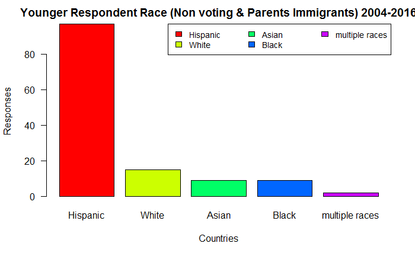

```r
race_column<-grep("race", colnames(unique_young))
race_cleaned<-unique_young[complete.cases(unique_young[race_column]),]

race_cleaned_table<-select(race_cleaned, race=race)

##Update to show country names

#convert column to string
string_column_race <- data.frame(lapply(race_cleaned_table, as.character), stringsAsFactors=FALSE)

#update each race
string_column_race[string_column_race$race == 5, "race"] <- "Hispanic"
string_column_race[string_column_race$race == 1, "race"] <- "White"
string_column_race[string_column_race$race == 3, "race"] <- "Asian"
string_column_race[string_column_race$race == 2, "race"] <- "Black"
string_column_race[string_column_race$race == 6, "race"] <- "multiple races"

x<-sort(table(string_column_race$race), decreasing = TRUE)

##add some color and labels
barplot(x,
        col = rainbow(length(x)),
        main = "Younger Respondent Race (Non voting & Parents Immigrants) 2004-2016",
        xlab = "Countries",
        ylab = "Responses",
        las = 1,
)
legend("topright",
       legend = row.names(x),
       fill = rainbow(length(x)), ncol = 3,
       cex = 0.9)
```

```r
invisible({capture.output({
dev.copy(png,'../figs/races.png')
dev.off()
})})
```

We see a clear pattern emerging. The group of younger children of immigrants who are not eligible to vote are now mostly Hispanic. There has been a shift in demographics of immigrants since the second half of the 20th century. How do we expect them to vote if they were given the ability to cast a ballot?

We see how the Hispanic vote might influence future elections since most dreamers are of Hispanic origin.

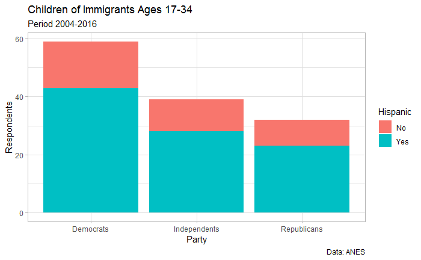

```r
stacked_bar<-select(unique_young_cleaned,
                    Hispanic = Hispanic_Origin,
                    Party_Affiliation = Political_View,
                    )

stacked_bar_grouped<-stacked_bar %>% group_by(Party_Affiliation, Hispanic) %>% summarise(count_val = n())

##Remove NA values
stacked_bar_grouped_cleaned<-stacked_bar_grouped[complete.cases(stacked_bar_grouped[2]),]

factor_stacked_bar_grouped<-as_factor(stacked_bar_grouped_cleaned,ordered = FALSE)

factor_stacked_bar_grouped <- data.frame(lapply(stacked_bar_grouped_cleaned, as.character), stringsAsFactors=FALSE)

#update each country
factor_stacked_bar_grouped[factor_stacked_bar_grouped$Party_Affiliation == 1, "Party_Affiliation"] <- "Democrats"
factor_stacked_bar_grouped[factor_stacked_bar_grouped$Party_Affiliation == 2, "Party_Affiliation"] <- "Independents"
factor_stacked_bar_grouped[factor_stacked_bar_grouped$Party_Affiliation == 3, "Party_Affiliation"] <- "Republicans"

factor_stacked_bar_grouped$count_val<-as.integer(factor_stacked_bar_grouped$count_val)

#change ethnicity to have more meaning
factor_stacked_bar_grouped[factor_stacked_bar_grouped$Hispanic == 1, "Hispanic"] <- "Yes"
factor_stacked_bar_grouped[factor_stacked_bar_grouped$Hispanic == 2, "Hispanic"] <- "No"


ggplot(data = factor_stacked_bar_grouped, aes(fill=Hispanic, y=count_val, x=Party_Affiliation)) + geom_bar(position='stack', stat='identity') + labs(
  title = "Children of Immigrants Ages 17-34",
  subtitle = "Period 2004-2016",
  caption = "Data: ANES",
  x = "Party",
  y = "Respondents"
  )
```

```r
invisible({capture.output({
dev.copy(png,'../figs/EthnicityOfDreamers.png')
dev.off()
})})
```

Final Thoughts

It is clear that if the current administration would like to remain in power it must take steps to [naturalize more undocumented immigrants](https://www.phoenixnewtimes.com/news/president-biden-arizona-doug-ducey-immigration-daca-border-wall-trump-11526981). However, the current administration should walk a thin line when it comes to the political spectrum. We see from our respondents that they are not extremely far left and therefore will vote accordingly if the current administration goes too far astray.